# Trees

A decision tree is a non-parametric learning method used for both classification and regression. It works by recursively partitioning the feature space into a set of rectangular regions, based on splitting rules that minimize an impurity measure (such as Gini index, entropy, or residual sum of squares). Each split aims to create more homogeneous subgroups in terms of the outcome variable. This process continues until a stopping criterion is met (e.g., minimum node size or maximum depth), or the tree is pruned to avoid overfitting.

For categorical outcomes, the tree assigns the majority class of training observations within each region to new data.

For numeric outcomes, the tree predicts the mean of the response values in the region.

Among supervised machine learning models, decision trees are the easiest to understand. They are computationally efficient, automatically handle variable selection, can model non-linear relationships and handle qualitative predictors. However, Trees tend to overfit the data and generally underperform other supervised learning methods in prediction. These two issues can be addressed by selecting better model hyperparameters. Hyperparameter values are evaluated and the one with the lowest cross-validation error selected.

### Use Cases

- Classifying customers as likely to churn or not
- Predicting default risk in credit scoring
- Diagnosing diseases based on clinical indicators
- Fraud detection in banking transactions
- Predicting equipment failure from sensor data

### Strengths

- Easy to interpret and explain to others
- Requires minimal preprocessing
  - No need to standardize numeric features
  - Can handle many types of predictors (sparse, skewed, continuous, categorical, etc.)
  - Handles missing values without imputation
  - Robust to outliers
- Efficient
  - Only uses features that contribute to prediction performance
- Flexible
  - Handles non-linear relationships and interactions
- Feature Selection
  - implicitly conduct feature selection. If a predictor is never used in a split, then the prediction equation is independent of it. However, this advantage is weakened for highly correlated predictors where the choice of which is used for a split is somewhat random.

### Weaknesses

- Less-than optimal predictive performance.
  - Tree models partition the predictor space into rectangular regions. If the relationship between predictors and outcome is not adequately described by these rectangles, performance will be poor.
  - Number of possible predicted outcomes is finite and is determined by the number of leaves. This limitation is unlikely to capture all the nuances of the data.
- Model instability
  - Slight changes in the data can drastically change the structure of the tree, hence the interpretation. Thus, these models have high variance. Easy to overfit train data.

## Overview

In this note, we will tune model hyperparameters for a Classification Tree using the same data on ad clicks. Next, we will tun model hyperparameters for a Regression Tree using home sales data.

```python
import numpy as np
import pandas as pd
import matplotlib.pyplot as plt

from sklearn.model_selection import train_test_split
from sklearn.metrics import accuracy_score, roc_auc_score
```

## Classification Tree

### … Clicks Data

This dataset describes user interactions with online advertisements for a digital marketing platform. It includes demographic, behavioral, and contextual features for 2000 users, along with whether each user clicked on an ad. The goal is to predict whether a person clicked on an ad.

Variable Description

- click: Whether the user clicked on the ad. 1 = Clicked, 0 = Did not click
- age: Age of the user in years
- gender: Gender of the user. 1 = Male, 2 = Female
- device: Device used to access the site. 1 = Mobile, 2 = Desktop, 3 = Tablet
- browser: Browser used to access the site 1 = Chrome, 2 = Safari, 3 = Firefox, 4 = Edge, 5 = Other
- time_on_site: Time (in seconds) spent on site before ad was shown
- pages_visited: Number of pages visited before ad was shown
- ad_position: Position where the ad appeared on the webpage. 1 = Top, 2 = Side, 3 = Bottom
- ad_type: Format of the ad shown. 1 = Banner, 2 = Video, 3 = Popup, 4 = Native
- is_weekend: Whether the ad impression occurred on a weekend. 1 = Weekend, 0 = Weekday
- user_logged_in: Whether the user was logged in when the ad was shown. 1 = Logged in, 0 = Anonymous
- past_click_rate: Historical average click-through rate for the user
- ad_relevance_score: Score from 1 to 10 indicating how relevant the ad is to the user profile

### Read Data

- Import data
- Separate Features from the Outcome, click

```python
clicks = pd.read_csv('clicks.csv')
clicks.head()
```

|  | click | age | gender | device | browser | time_on_site | pages_visited | ad_position | ad_type | is_weekend | user_logged_in | past_click_rate | ad_relevance_score |
| --- | --- | --- | --- | --- | --- | --- | --- | --- | --- | --- | --- | --- | --- |
| 0 | 0 | 50 | 2 | 2 | 1 | 211 | 1 | 3 | 4 | 1 | 1 | 0.069 | 7 |
| 1 | 0 | 57 | 1 | 1 | 3 | 251 | 4 | 2 | 3 | 0 | 1 | 0.043 | 6 |
| 2 | 1 | 68 | 1 | 1 | 2 | 222 | 2 | 2 | 1 | 0 | 1 | 0.073 | 9 |
| 3 | 0 | 30 | 2 | 2 | 1 | 206 | 2 | 1 | 1 | 0 | 1 | 0.147 | 4 |
| 4 | 0 | 60 | 2 | 1 | 2 | 183 | 6 | 2 | 3 | 0 | 1 | 0.183 | 5 |

```python
X = clicks.drop(['click'], axis=1)
y = clicks.click
```

### Split Data

```python
from sklearn.model_selection import train_test_split
X_train_raw, X_test_raw, y_train, y_test = train_test_split(X,y,
                                                   train_size=0.7,
                                                   random_state=617)
```

### Transform

- Nominal categorical features need to transformed before use in a predictive model.
- Each categorical feature with k levels is represented by k-1 dummy variables.

```python
X_train_raw.head()
```

|  | age | gender | device | browser | time_on_site | pages_visited | ad_position | ad_type | is_weekend | user_logged_in | past_click_rate | ad_relevance_score |
| --- | --- | --- | --- | --- | --- | --- | --- | --- | --- | --- | --- | --- |
| 1086 | 63 | 2 | 1 | 4 | 126 | 6 | 1 | 1 | 1 | 0 | 0.133 | 5 |
| 1162 | 47 | 2 | 1 | 1 | 203 | 8 | 2 | 4 | 1 | 1 | 0.076 | 5 |
| 1736 | 25 | 2 | 2 | 1 | 189 | 3 | 1 | 4 | 0 | 1 | 0.198 | 6 |
| 682 | 54 | 1 | 1 | 2 | 208 | 6 | 2 | 4 | 0 | 0 | 0.001 | 5 |
| 2 | 68 | 1 | 1 | 2 | 222 | 2 | 2 | 1 | 0 | 1 | 0.073 | 9 |

```python
categorical_features = ['gender', 'device', 'browser','ad_position', 'ad_type','is_weekend', 'user_logged_in']

X_train = pd.get_dummies(X_train_raw,
                         columns=categorical_features,
                         drop_first=True)

X_test = pd.get_dummies(X_test_raw,
                        columns=categorical_features,
                        drop_first=True).reindex(columns=X_train.columns, fill_value=0)

X_train.head()
```

|  | age | time_on_site | pages_visited | past_click_rate | ad_relevance_score | gender_2 | gender_3 | device_2 | device_3 | browser_2 | browser_3 | browser_4 | browser_5 | ad_position_2 | ad_position_3 | ad_type_2 | ad_type_3 | ad_type_4 | is_weekend_1 | user_logged_in_1 |
| --- | --- | --- | --- | --- | --- | --- | --- | --- | --- | --- | --- | --- | --- | --- | --- | --- | --- | --- | --- | --- |
| 1086 | 63 | 126 | 6 | 0.133 | 5 | True | False | False | False | False | False | True | False | False | False | False | False | False | True | False |
| 1162 | 47 | 203 | 8 | 0.076 | 5 | True | False | False | False | False | False | False | False | True | False | False | False | True | True | True |
| 1736 | 25 | 189 | 3 | 0.198 | 6 | True | False | True | False | False | False | False | False | False | False | False | False | True | False | True |
| 682 | 54 | 208 | 6 | 0.001 | 5 | False | False | False | False | True | False | False | False | True | False | False | False | True | False | False |
| 2 | 68 | 222 | 2 | 0.073 | 9 | False | False | False | False | True | False | False | False | True | False | False | False | False | False | True |

### Fit Default Tree

- For our default tree, we will set the max_depth to 4. This will serve as a baseline for comparing tuned models.
- Not setting max_depth will generate a maximal tree.

```python
from sklearn.tree import DecisionTreeClassifier, plot_tree
tree = DecisionTreeClassifier(random_state=617,
                              max_depth=4) # default is a maximal tree
tree.fit(X_train,y_train)
```

```
DecisionTreeClassifier(max_depth=4, random_state=617)
```

### Predict and Evaluate Performance of Default tree

We are making two kinds of predictions:

- Class predictions: Classify cases as 0 or 1.
- Probability predictions: Estimate probability (or likelihood) of each class.

Performance will be evaluated based on Accuracy and AUC.

- Accuracy: Proportion of correct predictions
- AUC: Area under the ROC curve

We are looking for high accuracy and AUC. Also, looking for a small gap between training and test performance.

```python
pred_train = tree.predict(X_train)
pred_test = tree.predict(X_test)
accuracy_train = accuracy_score(y_train, pred_train) # same as tree.score(X_train, y_train)
accuracy_test = accuracy_score(y_test, pred_test)   # same as tree.score(X_test, y_test)
pred_train_prob = tree.predict_proba(X_train)
pred_test_prob = tree.predict_proba(X_test)
auc_train = roc_auc_score(y_train, pred_train_prob[:,1])
auc_test = roc_auc_score(y_test, pred_test_prob[:,1])
print('train_accuracy', accuracy_train,
      '\n','test_accuracy', accuracy_test,
      '\n','auc_train',auc_train,
      '\n','auc_test',auc_test)
```

```
train_accuracy 0.7471428571428571
 test_accuracy 0.69
 auc_train 0.772630064732678
 auc_test 0.6473288060318116
```

### Model for Tuning

```python
from sklearn.tree import DecisionTreeClassifier, plot_tree
tree = DecisionTreeClassifier(random_state=617)
tree.get_params()
```

```
{'ccp_alpha': 0.0,
 'class_weight': None,
 'criterion': 'gini',
 'max_depth': None,
 'max_features': None,
 'max_leaf_nodes': None,
 'min_impurity_decrease': 0.0,
 'min_samples_leaf': 1,
 'min_samples_split': 2,
 'min_weight_fraction_leaf': 0.0,
 'monotonic_cst': None,
 'random_state': 617,
 'splitter': 'best'}
```

### Tune

Tuning the following three parameters.

- max_depth: The maximum depth of the tree
- min_samples_leaf: The minimum number of samples required to be at a leaf node.
- max_features: The number of features to consider when looking for the best split

Using 5-fold cross-validation. Cross-validation error metric is AUC.

```python
%%time
from sklearn.model_selection import GridSearchCV
param_grid = {'max_depth': [1, 2, 3, 4, 5, 6, 7, 8, 9, 10, 11, 12],
             'min_samples_leaf':[5, 10, 20, 40, 100, 150, 200],
             'max_features': [3, 4, 5, 6, 7, 8, 9, 10, 11, 12, 13, 14, 15, 16, 17, 18, 19, 20]}
tune_tree = GridSearchCV(estimator=tree,
                         param_grid=param_grid,
                         cv = 5,
                         scoring = 'roc_auc',
                         n_jobs = -1,
                         verbose=4)
tune_tree.fit(X_train, y_train)
```

```
Fitting 5 folds for each of 1512 candidates, totalling 7560 fits
CPU times: total: 7.05 s
Wall time: 1min 1s
```

```
GridSearchCV(cv=5, estimator=DecisionTreeClassifier(random_state=617),
             n_jobs=-1,
             param_grid={'max_depth': [1, 2, 3, 4, 5, 6, 7, 8, 9, 10, 11, 12],
                         'max_features': [3, 4, 5, 6, 7, 8, 9, 10, 11, 12, 13,
                                          14, 15, 16, 17, 18, 19, 20],
                         'min_samples_leaf': [5, 10, 20, 40, 100, 150, 200]},
             scoring='roc_auc', verbose=4)
```

Let us examine the cross-validation score (mean_test_score) for the models tested

```python
pd.DataFrame(tune_tree.cv_results_).head()
```

|  | mean_fit_time | std_fit_time | mean_score_time | std_score_time | param_max_depth | param_max_features | param_min_samples_leaf | params | split0_test_score | split1_test_score | split2_test_score | split3_test_score | split4_test_score | mean_test_score | std_test_score | rank_test_score |
| --- | --- | --- | --- | --- | --- | --- | --- | --- | --- | --- | --- | --- | --- | --- | --- | --- |
| 0 | 0.009216 | 0.000286 | 0.007494 | 0.000236 | 1 | 3 | 5 | {'max_depth': 1, 'max_features': 3, 'min_sampl... | 0.551007 | 0.537461 | 0.520619 | 0.632222 | 0.570367 | 0.562335 | 0.038564 | 1388 |
| 1 | 0.009417 | 0.000422 | 0.007760 | 0.000395 | 1 | 3 | 10 | {'max_depth': 1, 'max_features': 3, 'min_sampl... | 0.551007 | 0.537461 | 0.520619 | 0.632222 | 0.570367 | 0.562335 | 0.038564 | 1388 |
| 2 | 0.008410 | 0.000817 | 0.006901 | 0.000472 | 1 | 3 | 20 | {'max_depth': 1, 'max_features': 3, 'min_sampl... | 0.551007 | 0.537461 | 0.520619 | 0.632222 | 0.570367 | 0.562335 | 0.038564 | 1388 |
| 3 | 0.007705 | 0.000368 | 0.006320 | 0.000315 | 1 | 3 | 40 | {'max_depth': 1, 'max_features': 3, 'min_sampl... | 0.551007 | 0.537461 | 0.520619 | 0.632222 | 0.570367 | 0.562335 | 0.038564 | 1388 |
| 4 | 0.011005 | 0.002874 | 0.007248 | 0.001174 | 1 | 3 | 100 | {'max_depth': 1, 'max_features': 3, 'min_sampl... | 0.551007 | 0.537461 | 0.520619 | 0.632222 | 0.570367 | 0.562335 | 0.038564 | 1388 |

Next, we visualize the change in cross-validation AUC across values of hyperparameters. These plots examine each hyperparameter independently of others. However, the best model is one that is combination of all three hyperparameters with the best AUC.

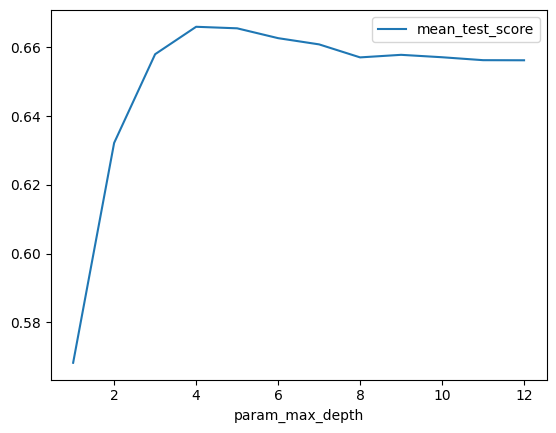

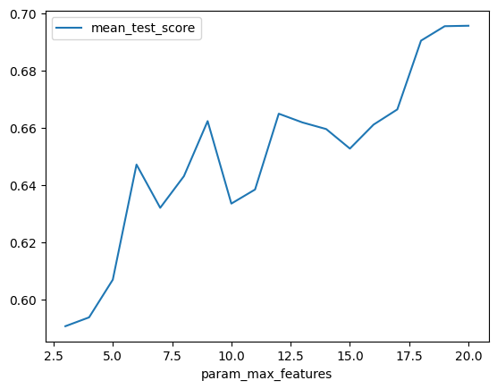

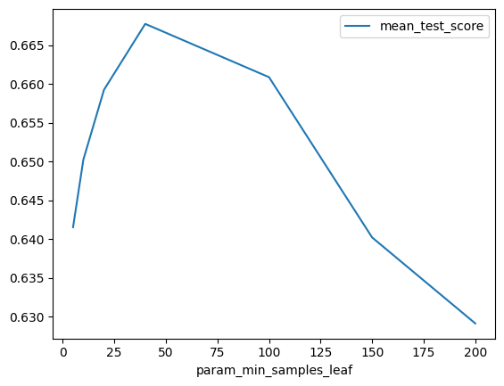

```python
cv_values = pd.DataFrame(tune_tree.cv_results_)
cv_values[['param_max_depth', 'mean_test_score']].groupby('param_max_depth').mean().plot()
cv_values[['param_max_features', 'mean_test_score']].groupby('param_max_features').mean().plot()
cv_values[['param_min_samples_leaf', 'mean_test_score']].groupby('param_min_samples_leaf').mean().plot()
plt.show()
```

```python
cv_values[['param_max_depth','param_max_features','param_min_samples_leaf','mean_test_score']].\
sort_values('mean_test_score', ascending=False).head(15)
```

|  | param_max_depth | param_max_features | param_min_samples_leaf | mean_test_score |
| --- | --- | --- | --- | --- |
| 368 | 3 | 19 | 100 | 0.721727 |
| 375 | 3 | 20 | 100 | 0.721727 |
| 361 | 3 | 18 | 100 | 0.721727 |
| 493 | 4 | 19 | 40 | 0.721104 |
| 627 | 5 | 20 | 100 | 0.720559 |
| 1257 | 10 | 20 | 100 | 0.720559 |
| 1383 | 11 | 20 | 100 | 0.720559 |
| 753 | 6 | 20 | 100 | 0.720559 |
| 1509 | 12 | 20 | 100 | 0.720559 |
| 879 | 7 | 20 | 100 | 0.720559 |
| 1005 | 8 | 20 | 100 | 0.720559 |
| 1131 | 9 | 20 | 100 | 0.720559 |
| 501 | 4 | 20 | 100 | 0.720559 |
| 1376 | 11 | 19 | 100 | 0.720121 |
| 1250 | 10 | 19 | 100 | 0.720121 |

```python
tune_tree.best_params_
```

```
{'max_depth': 3, 'max_features': 18, 'min_samples_leaf': 100}
```

```python
tune_tree.best_estimator_
```

```
DecisionTreeClassifier(max_depth=3, max_features=18, min_samples_leaf=100,
                       random_state=617)
```

### Evaluate Performance of Tuned Tree

```python
tune_tree.best_score_
```

```
np.float64(0.7217274035003596)
```

```python
best_tree = tune_tree.best_estimator_

print('train auc', best_tree.score(X_train, y_train),
      '\n','test auc', best_tree.score(X_test, y_test))
```

```
train auc 0.7271428571428571
 test auc 0.6916666666666667
```

### Inference

Visual representations of trees are powerful tools for understanding how the model makes decisions

- Feature importance: Most influential features appear near the top of the tree. Features used in earlier splits typically have a greater impact on prediction.
- Decision Rules: The tree explicitly shows rules used to split the data
- Structure: Tree represents the order in which features were considered and captures effects of combinations of features
- Cutoff values: Thresholds in the nodes represent key break points
- Leaf: Terminal nodes or leaves contain predictions
- Complexity: Depth of tree and number of nodes represent complexity of the tree model
- Leaf or Node Size: The number of observations in a node or leaf may represent the practical importance of the feature or cut-value

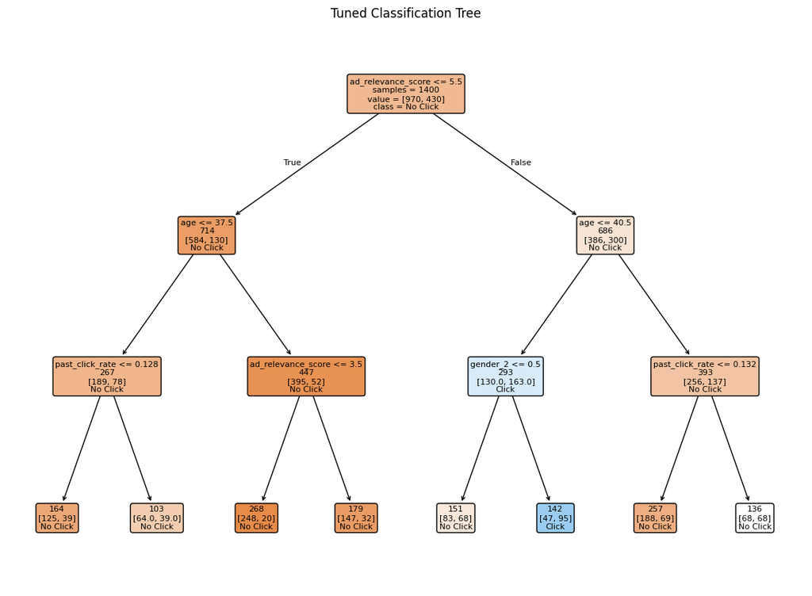

```python
plt.figure(figsize=(14, 10), facecolor='white')
plot_tree(best_tree,
          feature_names=X_train.columns,
          class_names=['No Click','Click'],
          filled=True,
          label='root',
          impurity=False,
          fontsize=8,
          rounded = True)
plt.title("Tuned Classification Tree")
plt.show()
```

## Regression Tree

### … House Sales

The data contains characteristics of houses and sales price for over 20,000 houses in the Seattle area (King County, WA) from May 2014 to May 2015. The goal of this assignment is to select useful features to use for prediction.

Variables

- id: Sales ID
- price: Sale price
- bedrooms: Number of bedrooms
- bathrooms: Number of bathrooms
- sqft_living: Area (in square feet) of the living area
- sqft_lot: Area (in square feet) of the land house is on
- floors: Number of floors (levels) in house
- waterfront: Whether the house has a view of the waterfront (0: No, 1: Yes)
- view: Rating of quality fo view (0-4)
- condition: Condition of the house (1-5, higher number indicates better condition)
- grade: Grade given to the housing unit, based on King County grading system (1-13, higher number indicates better grade)
- sqft_above: Area (in square feet) apart from basement
- sqft_basement: Area (in square feet) of the basement
- yr_built: Year the house was built
- yr_renovated: Year when house was renovated
- age: Age of house in years at time of sale

### Read Data

```python
houses = pd.read_csv('houses.csv')
X = houses.drop(['id','price','yr_built','yr_renovated'], axis = 1)
y = houses.price
```

### Split

```python
from sklearn.model_selection import train_test_split
y_binned = pd.qcut(y, q = 100)
X_train, X_test, y_train, y_test = train_test_split(X, y,
                 train_size = 0.7,
                 random_state = 617)
```

### Fit Default Tree

- For our default tree, we will set the max_depth to 4. This will serve as a baseline for comparing tuned models.
- Not setting max_depth will generate a maximal tree.

```python
from sklearn.tree import DecisionTreeRegressor, plot_tree
tree = DecisionTreeRegressor(random_state=617,
                             max_depth=4)
tree.fit(X_train, y_train)
```

```
DecisionTreeRegressor(max_depth=4, random_state=617)
```

### Evaluate Performance of Default Tree

```python
from sklearn.metrics import root_mean_squared_error
pred_train = tree.predict(X_train)
pred_test = tree.predict(X_test)
print('Train RMSE:', root_mean_squared_error(y_train, pred_train))
print('Test RMSE: ', root_mean_squared_error(y_test, pred_test))
```

```
Train RMSE: 222234.68175000354
Test RMSE:  225331.5182458686
```

### Model for Tuning

```python
from sklearn.tree import DecisionTreeRegressor, plot_tree
tree = DecisionTreeRegressor(random_state=617)
tree.get_params()
```

```
{'ccp_alpha': 0.0,
 'criterion': 'squared_error',
 'max_depth': None,
 'max_features': None,
 'max_leaf_nodes': None,
 'min_impurity_decrease': 0.0,
 'min_samples_leaf': 1,
 'min_samples_split': 2,
 'min_weight_fraction_leaf': 0.0,
 'monotonic_cst': None,
 'random_state': 617,
 'splitter': 'best'}
```

### Tune

Tuning the following three parameters.

- max_depth: The maximum depth of the tree
- min_samples_leaf: The minimum number of samples required to be at a leaf node.
- max_features: The number of features to consider when looking for the best split

Using 5-fold cross-validation. Cross-validation error metric is RMSE.

```python
%%time
from sklearn.model_selection import GridSearchCV
param_grid = {'max_depth': [2,3,4,5,6,7,8,9,10,11,12],
             'min_samples_leaf':[5, 10,20,40, 100, 150,200],
             'max_features': [1, 2, 3, 4, 5, 6, 7, 8, 9, 10, 11, 12]}
tune_tree = GridSearchCV(estimator=tree,
                         param_grid=param_grid,
                         cv = 5,
                         scoring = 'neg_root_mean_squared_error',
                         n_jobs = -1)
tune_tree.fit(X_train, y_train)
```

```
CPU times: total: 8.55 s
Wall time: 18.9 s
```

```
GridSearchCV(cv=5, estimator=DecisionTreeRegressor(random_state=617), n_jobs=-1,
             param_grid={'max_depth': [2, 3, 4, 5, 6, 7, 8, 9, 10, 11, 12],
                         'max_features': [1, 2, 3, 4, 5, 6, 7, 8, 9, 10, 11,
                                          12],
                         'min_samples_leaf': [5, 10, 20, 40, 100, 150, 200]},
             scoring='neg_root_mean_squared_error')
```

Let us examine the cross-validation score (mean_test_score) for the models tested

```python
pd.DataFrame(tune_tree.cv_results_).head()
```

|  | mean_fit_time | std_fit_time | mean_score_time | std_score_time | param_max_depth | param_max_features | param_min_samples_leaf | params | split0_test_score | split1_test_score | split2_test_score | split3_test_score | split4_test_score | mean_test_score | std_test_score | rank_test_score |
| --- | --- | --- | --- | --- | --- | --- | --- | --- | --- | --- | --- | --- | --- | --- | --- | --- |
| 0 | 0.007225 | 0.000162 | 0.002392 | 0.000112 | 2 | 1 | 5 | {'max_depth': 2, 'max_features': 1, 'min_sampl... | -254362.983031 | -284079.85645 | -304301.432056 | -315944.346308 | -306286.30315 | -292994.984199 | 21922.952177 | 918 |
| 1 | 0.007449 | 0.000365 | 0.002530 | 0.000123 | 2 | 1 | 10 | {'max_depth': 2, 'max_features': 1, 'min_sampl... | -254362.983031 | -284079.85645 | -304301.432056 | -315944.346308 | -306286.30315 | -292994.984199 | 21922.952177 | 918 |
| 2 | 0.007413 | 0.000101 | 0.002552 | 0.000134 | 2 | 1 | 20 | {'max_depth': 2, 'max_features': 1, 'min_sampl... | -254362.983031 | -284079.85645 | -304301.432056 | -315944.346308 | -306286.30315 | -292994.984199 | 21922.952177 | 918 |
| 3 | 0.007640 | 0.000170 | 0.002636 | 0.000088 | 2 | 1 | 40 | {'max_depth': 2, 'max_features': 1, 'min_sampl... | -254362.983031 | -284079.85645 | -304301.432056 | -315944.346308 | -306286.30315 | -292994.984199 | 21922.952177 | 918 |
| 4 | 0.007502 | 0.000165 | 0.002520 | 0.000128 | 2 | 1 | 100 | {'max_depth': 2, 'max_features': 1, 'min_sampl... | -254362.983031 | -284079.85645 | -304301.432056 | -315944.346308 | -306286.30315 | -292994.984199 | 21922.952177 | 918 |

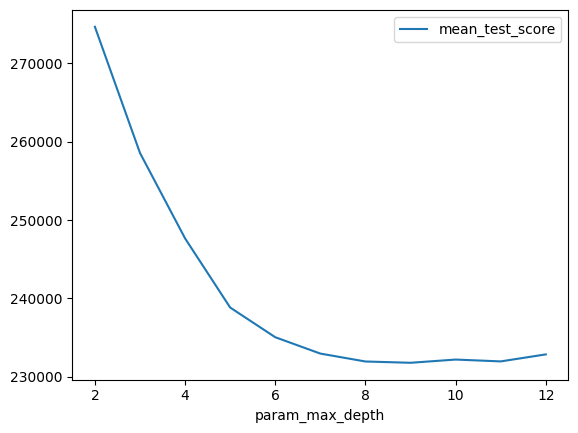

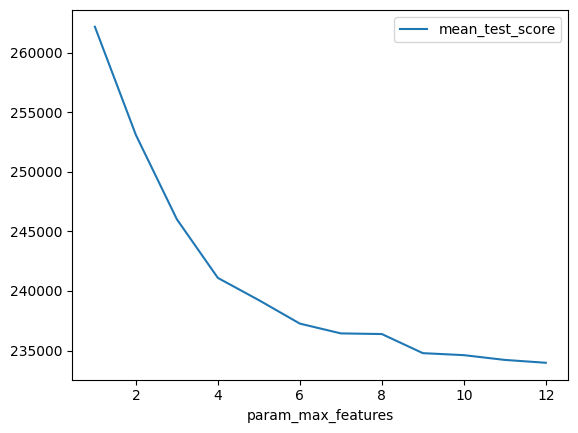

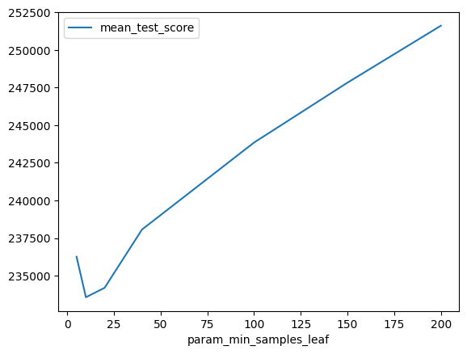

```python
cv_values = pd.DataFrame(tune_tree.cv_results_)
cv_values.mean_test_score = cv_values.mean_test_score*(-1)
cv_values[['param_max_depth', 'mean_test_score']].groupby('param_max_depth').mean().plot()
cv_values[['param_max_features', 'mean_test_score']].groupby('param_max_features').mean().plot()
cv_values[['param_min_samples_leaf', 'mean_test_score']].groupby('param_min_samples_leaf').mean().plot()
plt.show()
```

```python
cv_values[['param_max_depth','param_max_features','param_min_samples_leaf','mean_test_score']].\
sort_values('mean_test_score', ascending=True).head(15)
```

|  | param_max_depth | param_max_features | param_min_samples_leaf | mean_test_score |
| --- | --- | --- | --- | --- |
| 554 | 8 | 8 | 10 | 213674.331056 |
| 568 | 8 | 10 | 10 | 214237.151136 |
| 561 | 8 | 9 | 10 | 214418.667783 |
| 659 | 9 | 11 | 10 | 214508.588761 |
| 484 | 7 | 10 | 10 | 214810.494485 |
| 582 | 8 | 12 | 10 | 214944.939856 |
| 575 | 8 | 11 | 10 | 215219.393191 |
| 477 | 7 | 9 | 10 | 215254.942020 |
| 666 | 9 | 12 | 10 | 215439.016347 |
| 645 | 9 | 9 | 10 | 215469.019781 |
| 469 | 7 | 8 | 5 | 215649.114724 |
| 807 | 11 | 8 | 20 | 215779.542983 |
| 750 | 10 | 12 | 10 | 215833.099787 |
| 491 | 7 | 11 | 10 | 216255.394393 |
| 476 | 7 | 9 | 5 | 216271.853527 |

```python
tune_tree.best_params_
```

```
{'max_depth': 8, 'max_features': 8, 'min_samples_leaf': 10}
```

```python
best_tree = tune_tree.best_estimator_
```

### Performance of Tuned Tree

```python
- tune_tree.best_score_
```

```
np.float64(213674.33105550436)
```

```python
from sklearn.metrics import root_mean_squared_error
pred_train = best_tree.predict(X_train)
pred_test = best_tree.predict(X_test)
print('Train RMSE: ', root_mean_squared_error(y_train, pred_train))
print('Test RMSE: ', root_mean_squared_error(y_test, pred_test))
```

```
Train RMSE:  187978.7989350463
Test RMSE:  214850.38735279258
```

### Inference

- Best tree is a very large tree
- Therefore, we are only plotting a tree of depth 3

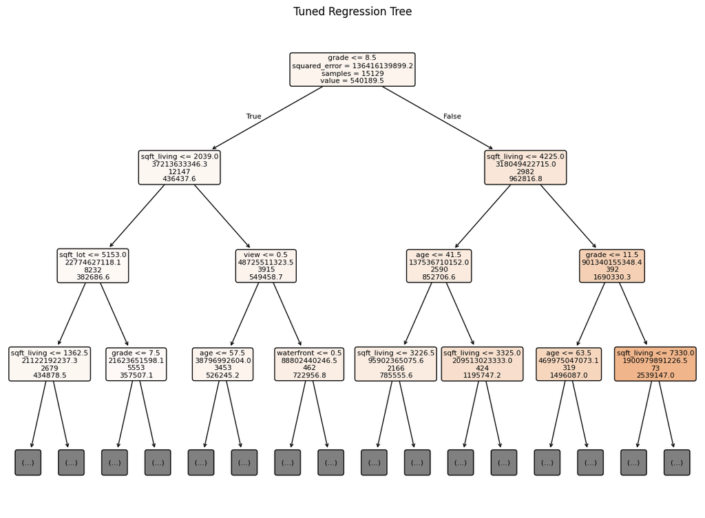

```python
from sklearn.tree import plot_tree

plt.figure(figsize=(14, 10))
plot_tree(best_tree,
          feature_names=X.columns,
          label = 'root',
          filled=True,
          fontsize=8,
          rounded = True,
          precision = 1,
          node_ids=False,
          max_depth = 3)
plt.title("Tuned Regression Tree")
plt.show()
```

## Summary

This note demonstrated methods to tune model hyperparameters for a Classification Tree and a Regression Tree.

```python
import platform
from IPython.display import display, HTML
import matplotlib
import sklearn as sklearn_complete
text = ('This file was generated using Python ' + platform.python_version() +\
      ' on a ' + platform.platform() + \
      ' system with Pandas ' + pd.__version__ + \
      ', Numpy ' + np.__version__ + \
      ', Matplotlib ' + matplotlib.__version__ + \
      ', Scikit-Learn ' + sklearn_complete.__version__ )

html = f"""
<hr style="border: 0; height: 1px; background: lightgray;" />
<p style="font-size: x-small; color: #555;">{text}</p>
"""

display(HTML(html))
```

This file was generated using Python 3.13.5 on a Windows-10-10.0.19045-SP0 system with Pandas 2.3.0, Numpy 2.3.1, Matplotlib 3.10.3, Scikit-Learn 1.7.1